# How did economic developments influence inaugural speeches?

### Introduction

Economic conditions are vital for a country’s development,that’ why every president talks at length about them during their inaugural speeches.However,there may exist a couple of differences in aspects of their speeches between prosperous years and depression years.Unfortunately,yet it’s only our guessing.In this analysis,we’ll see how economic development makes effects on presidents’ inaugual speeches.Besides,we compare two presidents, Roosevelt and Obama, both of whom experienced depression,and see what convergence and divergence are in their speeches.

## Step 0: check and install needed packages. Load the libraries and functions

```r
packages.used=c("tm", "wordcloud", "RColorBrewer",
                "dplyr", "tidytext")
# check packages that need to be installed.
packages.needed=setdiff(packages.used,
                        intersect(installed.packages()[,1],
                                  packages.used))
# install additional packages
if(length(packages.needed)>0){
  install.packages(packages.needed, dependencies = TRUE,
                   repos='http://cran.us.r-project.org')
}


library("rvest")
library("tibble")
library("qdap")
library("sentimentr")
library("gplots")
library("dplyr")
library("tm")
library("syuzhet")
library("factoextra")
library("scales")
library("RColorBrewer")
library("RANN")
library("topicmodels")
library("tidytext")
library("wordcloud")
library("beeswarm")


source("/Users/1/Desktop/ADS/Project 1/lib/speechFuncs.R")
source("/Users/1/Desktop/ADS/Project 1/lib/plotstacked.R")
```

## Step 1: scrap speech URLs from website and import GDP data from local file

```r
### Inauguaral speeches
main.page <- read_html(x = "http://www.presidency.ucsb.edu/inaugurals.php")
# Get link URLs
inaug=f.speechlinks(main.page)
inaug=inaug[-nrow(inaug),] # remove the last line, irrelevant due to error.
inaug.list=read.csv("/Users/1/Desktop/ADS/Project 1/data/inauglist.csv", stringsAsFactors = FALSE)
inaug.list=cbind(inaug.list,inaug)
inaug.list$type="inaug"


# Import economic data
gdp=read.csv("/Users/1/Desktop/ADS/Project 1/data/GDP.csv",skip=1,header=TRUE)
gdp=gdp[,-2]
names(gdp) <- c("year","growth")
gdp$year=as.Date(paste(gdp$year,"-12-31",sep=""))


inaug.list$Date=as.Date(inaug[,1], format="%B %e, %Y")

inaug.list=filter(inaug.list,Date>gdp$year[1])
inaug.list$growth=NA
for (i in seq(nrow(inaug.list)-1)){
  years<-filter(gdp,year>inaug.list$Date[i] & year<=inaug.list$Date[i+1])
  inaug.list$growth[i]=mean(years$growth)
}


# Loop over each row in inaug.list
inaug.list$fulltext=NA
for(i in seq(nrow(inaug.list))) {
  text <- read_html(inaug.list$urls[i]) %>% # load the page
    html_nodes(".displaytext") %>% # isloate the text
    html_text() # get the text
  inaug.list$fulltext[i]=text
  # Create the file name
  filename <- paste0("/Users/1/Desktop/ADS/Project 1/data/InauguralSpeeches/",
                     inaug.list$type[i],
                     inaug.list$File[i], "-",
                     inaug.list$Term[i], ".txt")
  sink(file = filename) %>% # open file to write
  cat(text)  # write the file
  sink() # close the file
}
```

In this step,only speeches given after 1929 are included because of the availability of economic data.

## Step 2: data Processing

```r
folder.path="/Users/1/Desktop/ADS/Project 1/data/InauguralSpeeches/"
speeches=list.files(path = folder.path, pattern = "*.txt")
prex.out=substr(speeches, 6, nchar(speeches)-4)

ff.all<-Corpus(DirSource(folder.path))

ff.all<-tm_map(ff.all, stripWhitespace)
ff.all<-tm_map(ff.all, content_transformer(tolower))
ff.all<-tm_map(ff.all, removeWords, stopwords("english"))
ff.all<-tm_map(ff.all, removeWords, character(0))
ff.all<-tm_map(ff.all, removePunctuation)
ff.all<-tm_map(ff.all, stemDocument)
```

For the speeches, we removed extra white space, converted all letters to the lower case, removed stop words, removed empty words due to formatting errors, and removed punctuation.

## Step 3: data analysis — topic modeling

Gengerated document-term matrices.

```r
dtm <- DocumentTermMatrix(ff.all)
#convert rownames to filenames
rownames(dtm) <- paste0(inaug.list$type, inaug.list$File,"_",inaug.list$Term)
rowTotals <- apply(dtm , 1, sum) #Find the sum of words in each Document
dtm  <- dtm[rowTotals> 0, ]
```

Run LDA

```r
#Set parameters for Gibbs sampling
burnin <- 4000
iter <- 1000
thin <- 500
seed <-list(2003,2,68,100001,765)
nstart <- 5
best <- TRUE

# Number of topics
k <- 15

# Run LDA using Gibbs sampling
ldaOut <-LDA(dtm, k, method="Gibbs", control=list(nstart=nstart,
                                                 seed = seed, best=best,
                                                 burnin = burnin, iter=iter,
                                                 thin=thin))
```

```r
# write out results
# docs to topics
ldaOut.topics <- as.matrix(topics(ldaOut))
write.csv(ldaOut.topics,file=paste("/Users/1/Desktop/ADS/Project 1/output/LDAGibbs",k,"DocsToTopics.csv"))

#top 6 terms in each topic
ldaOut.terms <- as.matrix(terms(ldaOut,15))
write.csv(ldaOut.terms,file=paste("/Users/1/Desktop/ADS/Project 1/output/LDAGibbs",k,"TopicsToTerms.csv"))

#probabilities associated with each topic assignment
topicProbabilities <- as.data.frame(ldaOut@gamma)
write.csv(topicProbabilities,file=paste("/Users/1/Desktop/ADS/Project 1/output/LDAGibbs",k,"TopicProbabilities.csv"))
# each row represents a document, and rowSum equals 1

# logarithmized parameters of the word distribution for each topic.
terms.beta=ldaOut@beta
terms.beta=scale(terms.beta)
topics.terms=NULL
for(i in 1:k){
  topics.terms=cbind(topics.terms, ldaOut@terms[order(terms.beta[i,], decreasing = TRUE)[1:10]]) # select 10 keywords for each topic
}

write.csv(topics.terms,file=paste("/Users/1/Desktop/ADS/Project 1/output/LDAGibbs",k,"TopicsKeywords.csv"))
```

```r
topics.hash=c("Tax", "Defense", "Crisis", "Economy", "America", "Prosperity", "Leadership", "Reform", "Liberty", "International", "Nation", "Freedom", "Democracy", "Misc", "Power")
inaug.list$ldatopic=as.vector(ldaOut.topics)
inaug.list$ldahash=topics.hash[ldaOut.topics]

colnames(topicProbabilities)=topics.hash
inaug.list.df=cbind(inaug.list, topicProbabilities)
```

Economic condition changes over time

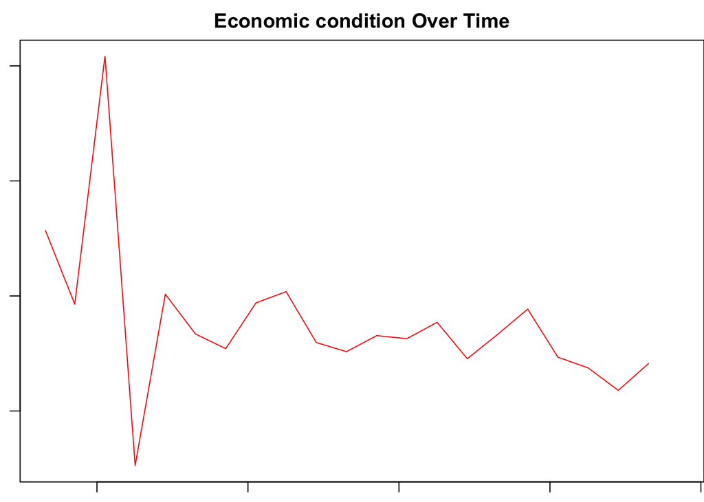

```r
par(mar=c(1,1,2,0))
plot(inaug.list.df$Date,inaug.list.df$growth,ylab="GDP Growth %",xlab="Year",main="Economic condition Over Time",type="l",col=2)
```

Different topics were chosen during different periods of time

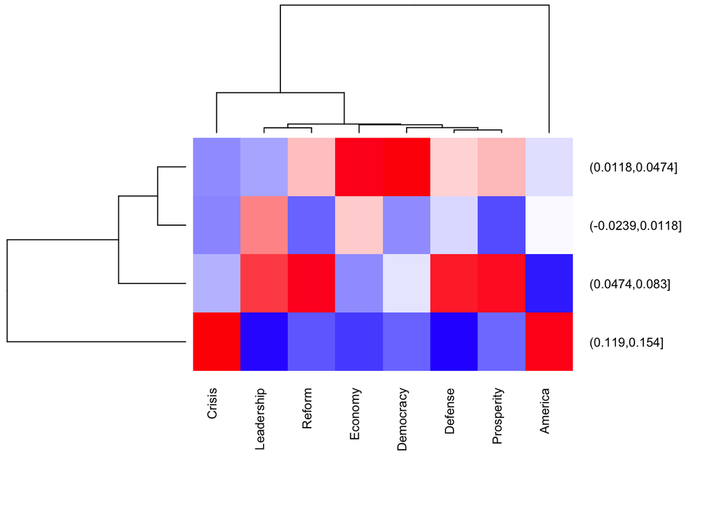

```r
par(mar=c(1,1,1,1))

inaug.list.df$growth[nrow(inaug.list.df)]=0
inaug.list.df$growth2=NULL
inaug.list.df$growth2<-cut(inaug.list.df$growth,breaks=5)

topic.summary2=tbl_df(inaug.list.df)%>%
              group_by(growth2)%>%
              select(growth2, Tax:Power)%>%
              summarise_each(funs(mean))
topic.summary2=as.data.frame(topic.summary2)
rownames(topic.summary2)=topic.summary2[,1]

topic.plot=c(2:6,7,8,13)

heatmap.2(as.matrix(topic.summary2[,topic.plot+1]),
          scale = "column", key=F,
          col = bluered(100),
          cexRow = 0.9, cexCol = 0.9, margins = c(8, 8),
          trace = "none", density.info = "none")
```

```r
inaug.list.df[which.max(inaug.list.df$growth),]$President
```

```
## [1] "Franklin D. Roosevelt"
```

```r
inaug.list.df[which.min(inaug.list.df$growth),]$President
```

```
## [1] "Franklin D. Roosevelt"
```

Roosevelt is the president in the year with both highest and lowest GDP growth rate.

## Step 3: data analysis — wordcloud comparison

There were two devestating economic depressions in American history.One is the Great Depression in 1929,when Roosevelt was president of U.S.Another one happened in 2008,Obama became president at that point.So many news reports talked about the similarities between them.Let’s make it more detailed with wordcloud and emotion analysis.

This is Roosevelt’s wordcloud.

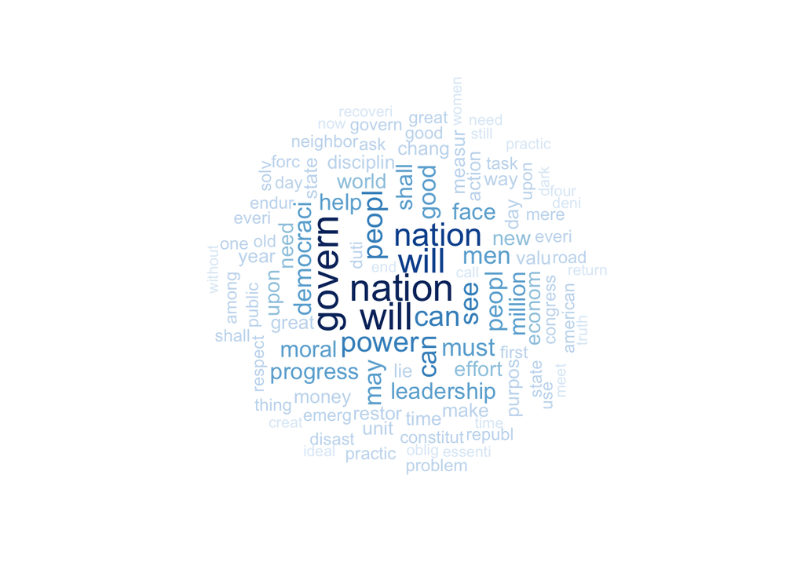

```r
tdm.all<-TermDocumentMatrix(ff.all)
tdm.tidy=tidy(tdm.all)
tdm.all = subset(tdm.tidy,document == 'inaugFranklinDRoosevelt-1.txt'|document =='inaugFranklinDRoosevelt-2.txt')
#tdm.overall=summarise(group_by(tdm.tidy, term), sum(count))
wordcloud(tdm.all$term, tdm.all$count,
          scale=c(2,0.5),
          max.words=100,
          min.freq=1,
          random.order=FALSE,
          rot.per=0.3,
          use.r.layout=T,
          random.color=FALSE,
          colors=brewer.pal(9,"Blues"))
```

This is Obama’s wordcloud.

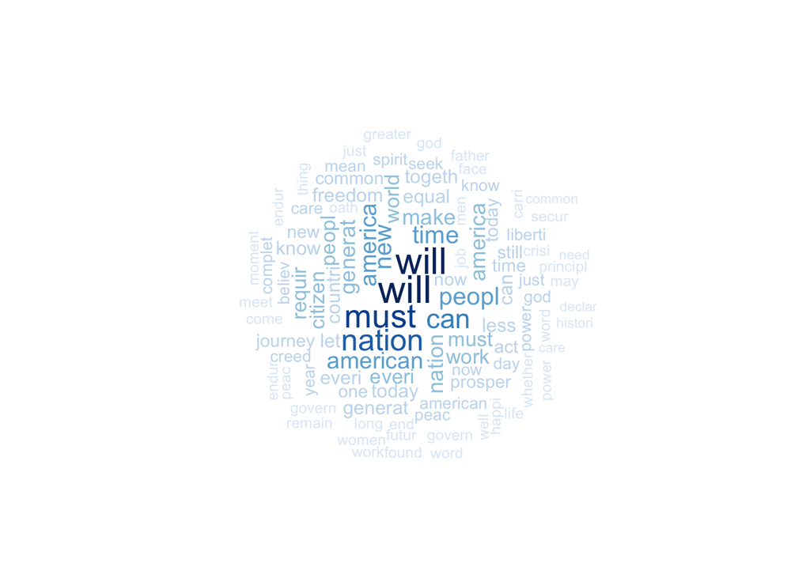

```r
tdm.all<-TermDocumentMatrix(ff.all)
tdm.tidy=tidy(tdm.all)
tdm.all = subset(tdm.tidy,document == 'inaugBarackObama-1.txt'|document =='inaugBarackObama-2.txt')
#tdm.overall=summarise(group_by(tdm.tidy, term), sum(count))
wordcloud(tdm.all$term, tdm.all$count,
          scale=c(2,0.5),
          max.words=100,
          min.freq=1,
          random.order=FALSE,
          rot.per=0.3,
          use.r.layout=T,
          random.color=FALSE,
          colors=brewer.pal(9,"Blues"))
```

From the two pictures we got,we can easily find both Roosevelt’s and Obama’s focus on national development and human rights.Besides,although they used economic words like work, money etc,powerful words such as effort,million,duty were used more often by Roosevelt than Obama,as shown in picture one.The Great Depression was worse than the financial crisis that happened in 2008,that’s why Roosevelt used more emotional and economic words compared to Obama.It agrees with our original thoughts.

## Step 3: data analysis — emotion analysis

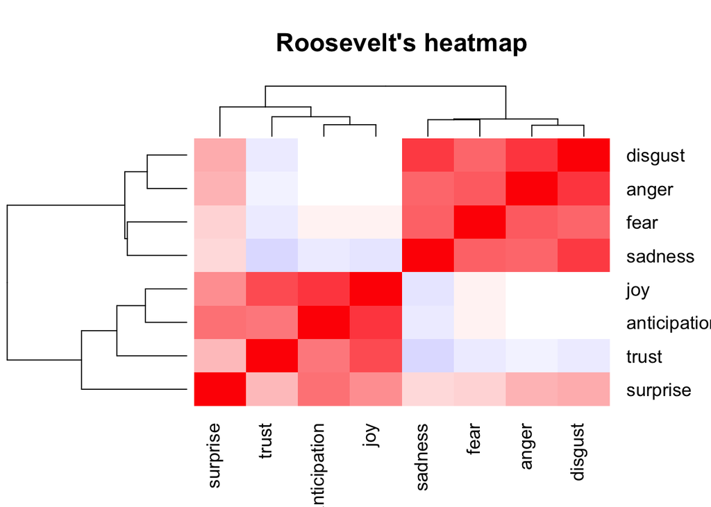

```r
sentence.list=NULL
for(i in 1:nrow(inaug.list)){
  sentences=sent_detect(inaug.list$fulltext[i],
                        endmarks = c("?", ".", "!", "|",";"))
  if(length(sentences)>0){
    emotions=get_nrc_sentiment(sentences)
    word.count=word_count(sentences)
    # colnames(emotions)=paste0("emo.", colnames(emotions))
    # in case the word counts are zeros?
    emotions=diag(1/(word.count+0.01))%*%as.matrix(emotions)
    sentence.list=rbind(sentence.list,
                        cbind(inaug.list[i,-ncol(inaug.list)],
                              sentences=as.character(sentences),
                              word.count,
                              emotions,
                              sent.id=1:length(sentences)
                              )
    )
  }
}
sentence.list=
  sentence.list%>%
  filter(!is.na(word.count))


sel.comparison2=c("FranklinDRoosevelt")
sentence.list1=filter(sentence.list,
                       File%in%sel.comparison2)
heatmap.2(cor(sentence.list1%>%select(anger:trust)),
          scale = "none",
          col = bluered(100), , margin=c(6, 6), key=F,
          trace = "none", density.info = "none",main="Roosevelt's heatmap")
```

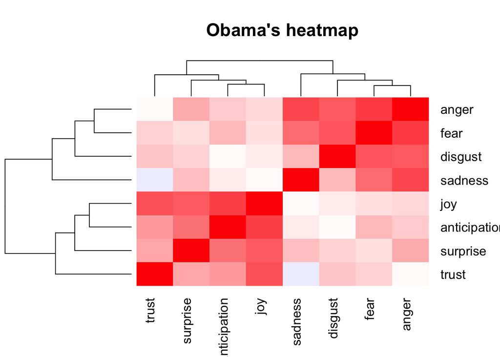

```r
sel.comparison3=c("BarackObama")
sentence.list2=filter(sentence.list,
                       File%in%sel.comparison3)
heatmap.2(cor(sentence.list2%>%select(anger:trust)),
          scale = "none",
          col = bluered(100), , margin=c(6, 6), key=F,
          trace = "none", density.info = "none",main="Obama's heatmap")
```

### Conclusion

Moreover,Roosevelt became the president of the U.S. while the Great Depression was happening.However,with a lot of hard work he made the GDP increase tremendously,even the highest GDP in the next few years.This is a strong proof for how efficient and powerful Roosevelt’s policy was.